# Assignment 1

Reece Wooten

11/4/2017

```r
# read csv file and make it a time series object
RS<-read.csv(file="RSGCSN.csv") %>%
  select(-DATE) %>%
  ts(start=c(1992,1),frequency=12)

# training and test set split
tr<-window(RS,end=c(2011,12))
te<-window(RS,start=c(2012,1))
```

## Question 1

### Figure 1.0

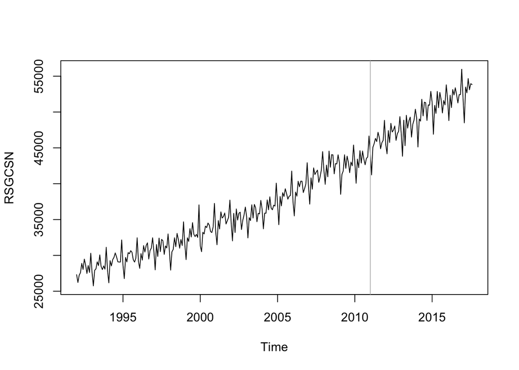

```r
# plotting full data
plot(RS)
abline(v=c(2011,12),col='grey')
```

```r
# model fit and summary
f.HW<-ets(tr,model = 'AAM',restrict=FALSE,damped = NULL)
summary(f.HW)
```

```
## ETS(A,Ad,M)
##
## Call:
##  ets(y = tr, model = "AAM", damped = NULL, restrict = FALSE)
##
##   Smoothing parameters:
##     alpha = 0.2604
##     beta  = 0.0352
##     gamma = 1e-04
##     phi   = 0.9773
##
##   Initial states:
##     l = 27872.6554
##     b = 51.6424
##     s=1.0665 0.9957 0.9982 0.9782 1.017 1.0313
##            0.999 1.0303 0.9799 1.0008 0.9174 0.9856
##
##   sigma:  535.0611
##
##      AIC     AICc      BIC
## 4366.896 4369.991 4429.548
##
## Training set error measures:
##                    ME     RMSE      MAE       MPE     MAPE      MASE
## Training set 50.63423 535.0611 412.6889 0.1190334 1.175391 0.4067623
##                    ACF1
## Training set -0.2637045
```

```r
# forecast
fc.HW<-forecast(f.HW,h = 68)
```

### Figure 1.1

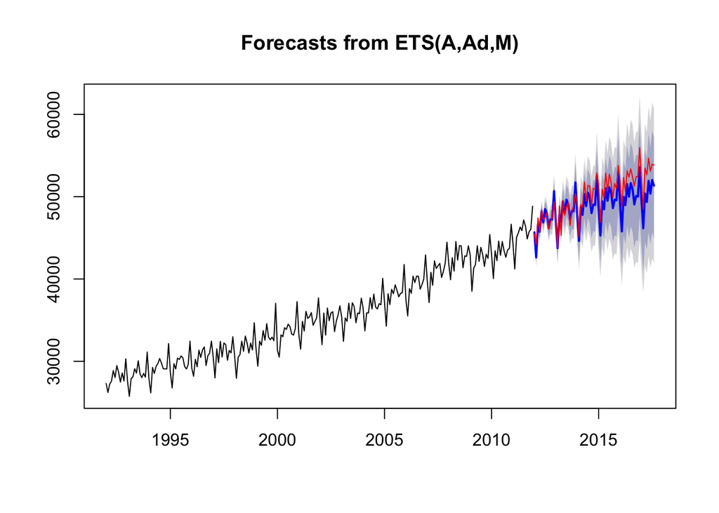

```r
# full forecast plot
plot(fc.HW)
lines(te,col='red',pch=19)
```

### Figure 1.2

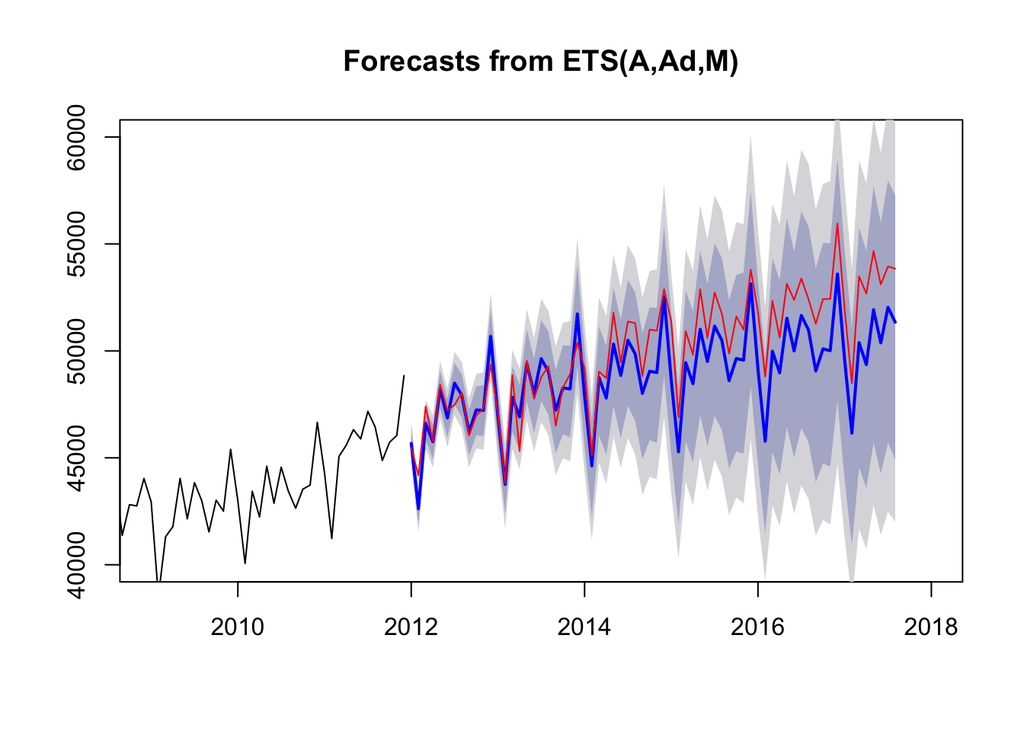

```r
# zoomed in forcast plot
plot(fc.HW,xlim=c(2009,2018),ylim = c(40000,60000))
lines(te,col='red',pch=19)
```

```r
# test,training accuracy
accuracy(fc.HW,te)
```

```
##                      ME      RMSE       MAE       MPE     MAPE      MASE
## Training set   50.63423  535.0611  412.6889 0.1190334 1.175391 0.4067623
## Test set     1114.01135 1614.8850 1340.8976 2.1517677 2.626992 1.3216410
##                    ACF1 Theil's U
## Training set -0.2637045        NA
## Test set      0.6409933 0.6517983
```

## Question 2

```r
# Model fit with damped=false
f.HW2<-ets(y = tr,model = 'AAM',restrict=FALSE,damped = FALSE)
summary(f.HW2)
```

```
## ETS(A,A,M)
##
## Call:
##  ets(y = tr, model = "AAM", damped = FALSE, restrict = FALSE)
##
##   Smoothing parameters:
##     alpha = 0.2309
##     beta  = 0.0548
##     gamma = 1e-04
##
##   Initial states:
##     l = 27872.6548
##     b = 39.6952
##     s=1.0656 0.9963 0.9961 0.9763 1.0161 1.0324
##            1.0006 1.0314 0.9793 1.0003 0.9189 0.9868
##
##   sigma:  539.3223
##
##      AIC     AICc      BIC
## 4368.704 4371.460 4427.875
##
## Training set error measures:
##                    ME     RMSE      MAE         MPE     MAPE      MASE
## Training set 7.459114 539.3223 424.2015 0.002428398 1.208207 0.4181095
##                    ACF1
## Training set -0.2116462
```

### Figure 2.0

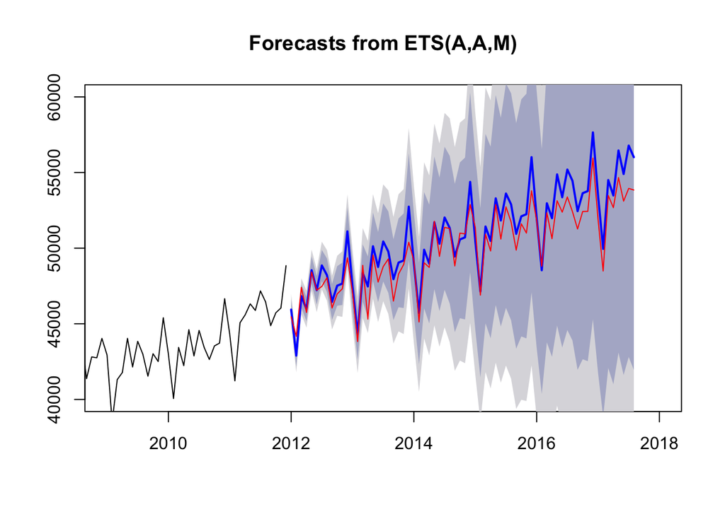

```r
# Plot forecasts along with actuals
fc.HW2<-forecast(f.HW2,h = 68)
plot(fc.HW2,xlim=c(2009,2018),ylim = c(40000,60000))
lines(te,col='red',pch=19)
```

```r
# test and training set accuracy
accuracy(fc.HW2,te)
```

```
##                       ME      RMSE      MAE          MPE     MAPE
## Training set    7.459114  539.3223 424.2015  0.002428398 1.208207
## Test set     -818.368078 1156.6407 948.5997 -1.602851573 1.874100
##                   MASE       ACF1 Theil's U
## Training set 0.4181095 -0.2116462        NA
## Test set     0.9349769  0.2732119 0.4707054
```

### Analysis

- The out of sample MAE is 948, compared to the previous question with a MAE of 1340. This indicates that the second model has less bias than the first one, the MASE is also better than the first model with a value of .93. This indicates that the model does a slightly better job at forecasting than the naive method.
- I suspect the reason why the confidence interval is much larger in the second problem is because we forced the damped term to be false. While it improved our point estimates, it lowered the confidence on the models fit.
- I would use model two’s estimates because it has better measures of fit, including the RMSE, and MASE.

## Question 3

```r
f.O<-ets(y = tr,model = 'ZZZ',restrict = FALSE)
summary(f.O)
```

```
## ETS(M,A,A)
##
## Call:
##  ets(y = tr, model = "ZZZ", restrict = FALSE)
##
##   Smoothing parameters:
##     alpha = 0.236
##     beta  = 0.0039
##     gamma = 0.0023
##
##   Initial states:
##     l = 27993.6515
##     b = 50.6138
##     s=2422.773 -185.2055 -145.3778 -792.2986 575.7059 1157.738
##            24.5534 1137.507 -735.0461 25.3615 -2791.01 -694.7011
##
##   sigma:  0.0149
##
##      AIC     AICc      BIC
## 4351.995 4354.751 4411.165
##
## Training set error measures:
##                   ME    RMSE      MAE       MPE     MAPE      MASE
## Training set 51.6301 528.882 407.0936 0.1137527 1.155015 0.4012474
##                    ACF1
## Training set -0.2414475
```

### Figure 3.0

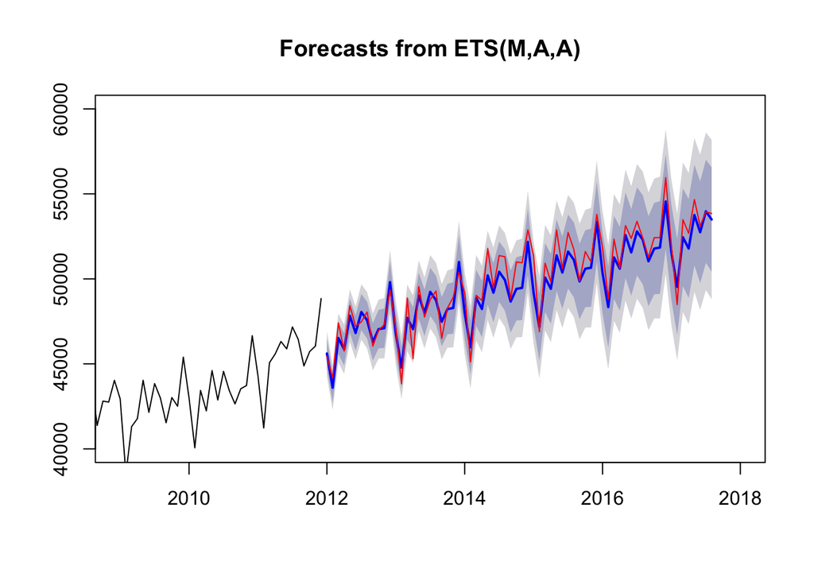

```r
fc.O<-forecast(f.O,h=68)
plot(fc.O,xlim=c(2009,2018),ylim=c(40000,60000))
lines(te,col='red',pch=19)
```

```r
accuracy(fc.O,te)
```

```
##                    ME    RMSE      MAE       MPE     MAPE      MASE
## Training set  51.6301 528.882 407.0936 0.1137527 1.155015 0.4012474
## Test set     414.1077 824.554 670.8440 0.7841938 1.334828 0.6612101
##                    ACF1 Theil's U
## Training set -0.2414475        NA
## Test set     -0.1113043 0.3423287
```

## Question 4

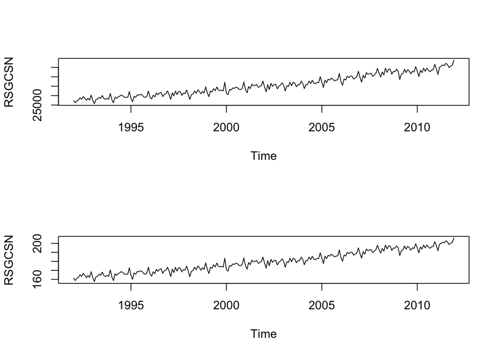

```r
L<-BoxCox.lambda(tr)
z<-BoxCox(tr,L)
par(mfrow=c(2,1))
plot(tr)
plot(z)
```

```r
par(mfrow=c(1,1))
```

```r
fB.O<-ets(y = tr,model = 'ZZZ',restrict = FALSE,lambda = L)
summary(fB.O)
```

```
## ETS(M,A,A)
##
## Call:
##  ets(y = tr, model = "ZZZ", lambda = L, restrict = FALSE)
##
##   Box-Cox transformation: lambda= 0.4125
##
##   Smoothing parameters:
##     alpha = 0.2539
##     beta  = 1e-04
##     gamma = 1e-04
##
##   Initial states:
##     l = 162.9948
##     b = 0.1533
##     s=5.2425 -0.4039 -0.2528 -1.673 1.2563 2.4717
##            0.1208 2.4657 -1.5866 0.0298 -6.2827 -1.3877
##
##   sigma:  0.0061
##
##      AIC     AICc      BIC
## 1389.165 1391.922 1448.336
##
## Training set error measures:
##                    ME     RMSE      MAE         MPE    MAPE      MASE
## Training set 16.19076 517.4893 394.0639 0.002165623 1.12071 0.3884048
##                    ACF1
## Training set -0.2668116
```

### Figure 4.0

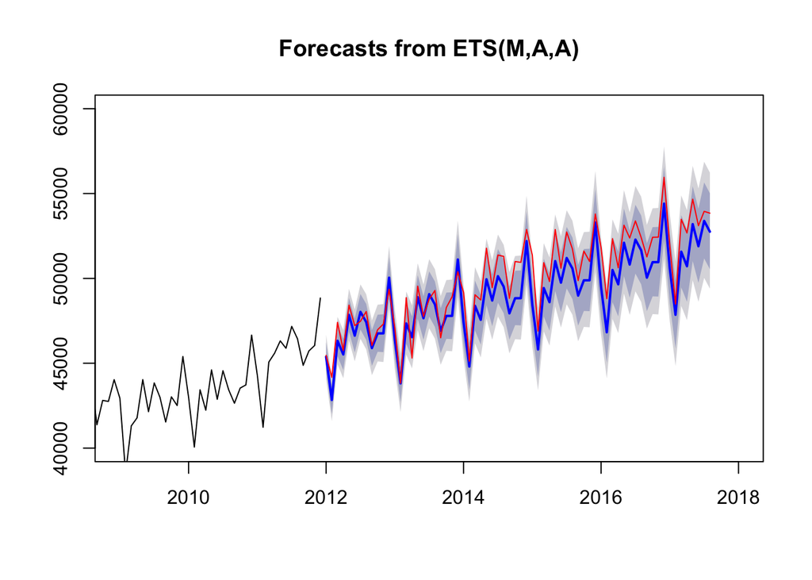

```r
fBc.O<-forecast(fB.O,h = 68)
plot(fBc.O,xlim = c(2009,2018),ylim = c(40000,60000))
lines(te,col='red',pch=19)
```

```r
accuracy(fBc.O,te)
```

```
##                     ME      RMSE       MAE         MPE     MAPE      MASE
## Training set  16.19076  517.4893  394.0639 0.002165623 1.120710 0.3884048
## Test set     972.04951 1244.6954 1086.2439 1.902816350 2.142824 1.0706444
##                    ACF1 Theil's U
## Training set -0.2668116        NA
## Test set      0.1870965 0.5110618
```

### Analysis

- The out of sample MAE is 1086 and the MASE is 1.07 which indicates a reduction in fit compared to the previous model. The naive estimate does a better job at forecasting than the model does. This is likely because a box cox was fit to the entire data set when not all periods were needed.
- I would choose model fc.O because it has better MASE and RMSE out of sample scores.

## Question 5

```r
fB.OD<-ets(y = tr,model = 'ZZZ',damped = TRUE,lambda = L)
summary(fB.OD)
```

```
## ETS(A,Ad,A)
##
## Call:
##  ets(y = tr, model = "ZZZ", damped = TRUE, lambda = L)
##
##   Box-Cox transformation: lambda= 0.4125
##
##   Smoothing parameters:
##     alpha = 0.2085
##     beta  = 0.0646
##     gamma = 1e-04
##     phi   = 0.9401
##
##   Initial states:
##     l = 162.9976
##     b = 0.1762
##     s=5.0803 -0.3646 -0.311 -1.713 1.2484 2.5376
##            0.0951 2.3793 -1.6005 -0.0512 -6.1441 -1.1563
##
##   sigma:  1.0978
##
##      AIC     AICc      BIC
## 1396.151 1399.246 1458.802
##
## Training set error measures:
##                    ME     RMSE      MAE       MPE     MAPE      MASE
## Training set 63.83274 520.9575 411.0406 0.1577651 1.165703 0.4051377
##                    ACF1
## Training set -0.2524737
```

### Figure 5.0

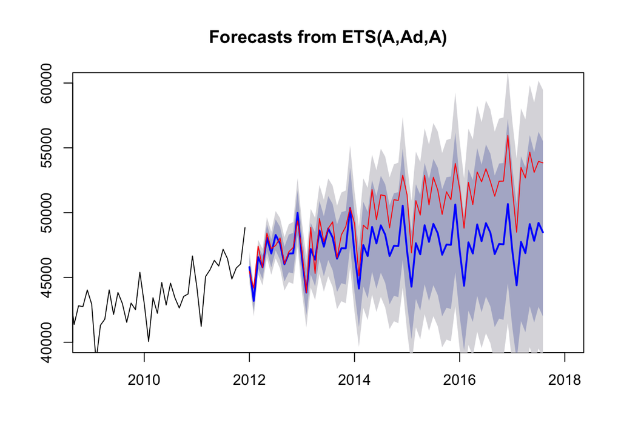

```r
fBc.OD<-forecast(fB.OD,h=68)
plot(fBc.OD,xlim = c(2009,2018),ylim = c(40000,60000))
lines(te,col='red',pch=19)
```

```r
accuracy(fBc.OD,te)
```

```
##                      ME      RMSE       MAE       MPE     MAPE      MASE
## Training set   63.83274  520.9575  411.0406 0.1577651 1.165703 0.4051377
## Test set     2541.68809 3184.8449 2625.8464 4.9233664 5.103323 2.5881368
##                    ACF1 Theil's U
## Training set -0.2524737        NA
## Test set      0.8392161  1.279647
```

## Question 6

```r
lis<-list()
for(year in seq(1992,2006)){
  RS<-read.csv(file='RSGCSN.csv') %>%
  select(-DATE) %>%
  ts(start=c(1992,1),frequency=12)

  tr<-window(RS,start = c(year,1), end = c(2011,12))
  te<-window(RS,start=c(2012,1))

  L<-BoxCox.lambda(tr)
  fB.O<-ets(y = tr,model = 'ZZZ',restrict = FALSE,lambda = L)

  cat('\n-------------------------------------')

  cat('Starting Year:',year)

  cat('--------------------------------\n')

  a=accuracy(fB.O)['Training set','RMSE']
  cat('RMSE:',accuracy(fB.O)['Training set','RMSE'])
  lis[[year]]<-a

}
```

```
##
## -------------------------------------Starting Year: 1992--------------------------------
## RMSE: 517.4893
## -------------------------------------Starting Year: 1993--------------------------------
## RMSE: 516.5789
## -------------------------------------Starting Year: 1994--------------------------------
## RMSE: 520.9142
## -------------------------------------Starting Year: 1995--------------------------------
## RMSE: 520.6291
## -------------------------------------Starting Year: 1996--------------------------------
## RMSE: 527.6315
## -------------------------------------Starting Year: 1997--------------------------------
## RMSE: 528.599
## -------------------------------------Starting Year: 1998--------------------------------
## RMSE: 530.4206
## -------------------------------------Starting Year: 1999--------------------------------
## RMSE: 536.8485
## -------------------------------------Starting Year: 2000--------------------------------
## RMSE: 532.4551
## -------------------------------------Starting Year: 2001--------------------------------
## RMSE: 515.7292
## -------------------------------------Starting Year: 2002--------------------------------
## RMSE: 511.8937
## -------------------------------------Starting Year: 2003--------------------------------
## RMSE: 494.1545
## -------------------------------------Starting Year: 2004--------------------------------
## RMSE: 508.9195
## -------------------------------------Starting Year: 2005--------------------------------
## RMSE: 512.3342
## -------------------------------------Starting Year: 2006--------------------------------
## RMSE: 515.5741
```

### Analysis

- The AICc and BIC are not comparable between models because they use different sets of data to fit the models. Only models which use the same data sets can be compared via AICc and BIC.

## Question 7

```r
RS<-read.csv(file='RSGCSN.csv') %>%
  select(-DATE) %>%
  ts(start=c(1992,1),frequency=12)


trr<-window(RS,start=c(2003,1), end=c(2011,12))
te<-window(RS,start=c(2012,1))
```

```r
L<-BoxCox.lambda(trr)
f<-ets(y = trr,model = 'ZZZ',restrict = FALSE,lambda = L)
summary(f)
```

```
## ETS(M,A,A)
##
## Call:
##  ets(y = trr, model = "ZZZ", lambda = L, restrict = FALSE)
##
##   Box-Cox transformation: lambda= 0.5078
##
##   Smoothing parameters:
##     alpha = 0.3437
##     beta  = 1e-04
##     gamma = 1e-04
##
##   Initial states:
##     l = 399.3291
##     b = 0.5507
##     s=12.9335 -0.5228 -0.9083 -5.3871 2.8785 6.4737
##            -0.1923 7.1417 -3.9767 -0.0233 -17.2089 -1.208
##
##   sigma:  0.0062
##
##      AIC     AICc      BIC
## 749.5679 756.3679 795.1641
##
## Training set error measures:
##                    ME     RMSE     MAE        MPE      MAPE      MASE
## Training set 1.138946 494.1545 372.665 -0.0121768 0.9224311 0.2750316
##                    ACF1
## Training set -0.1857008
```

### Figure 7.0

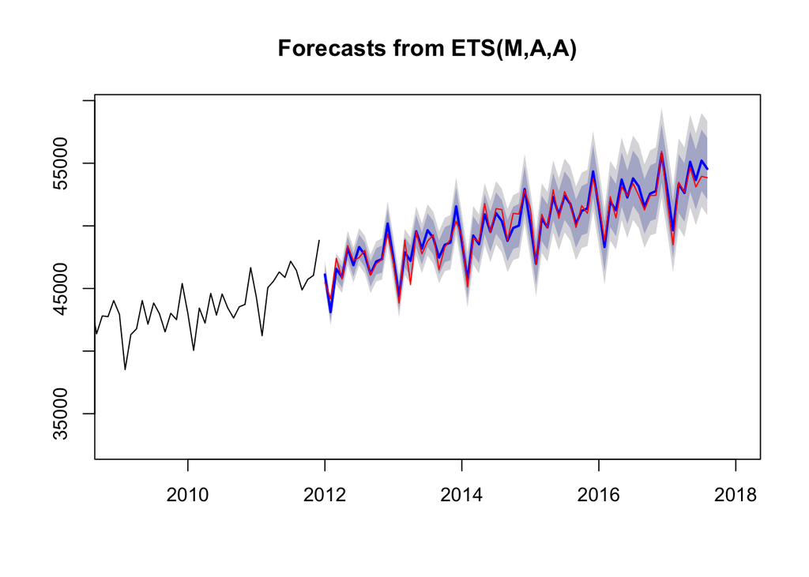

```r
fc<-forecast(f,h = 68)
plot(fc,xlim = c(2009,2018))
lines(te,col='red',pch=19)
```

```r
accuracy(fc,te)
```

```
##                      ME     RMSE      MAE        MPE      MAPE      MASE
## Training set   1.138946 494.1545 372.6650 -0.0121768 0.9224311 0.2750316
## Test set     -89.304138 627.4568 495.1071 -0.1852254 0.9977177 0.3653955
##                     ACF1 Theil's U
## Training set -0.18570080        NA
## Test set      0.01993697 0.2604248
```

### Analysis

- No, the AICc for model f.O and f can not compared. This is because the models were estimated by different data sets, and so there measures of fit are different.
- The MASE can be compared between f.O and f because it is a scale free measure of accuracy against the naive forecast.
- Because the data is the same between the two models forecasts and r transforms them back into the original units you can compare the two models RMSE.
- Because the model is only trained on the data before the forecast, the forecast is truly an out of sample forecast.

## Question 8

```r
RS<-read.csv(file='RSGCSN.csv') %>%
  select(-DATE) %>%
  ts(start=c(1992,1),frequency=12)


tr<-window(RS,start=c(2003,1),end=c(2017,8))
```

```r
L<-BoxCox.lambda(tr)
ff<-ets(y = tr,model = 'ZZZ',restrict = FALSE,lambda = L)
summary(ff)
```

```
## ETS(A,A,A)
##
## Call:
##  ets(y = tr, model = "ZZZ", lambda = L, restrict = FALSE)
##
##   Box-Cox transformation: lambda= 0.4567
##
##   Smoothing parameters:
##     alpha = 0.2914
##     beta  = 1e-04
##     gamma = 1e-04
##
##   Initial states:
##     l = 259.3136
##     b = 0.3076
##     s=7.0863 -0.0791 -0.2422 -3.407 1.9267 3.5662
##            0.01 4.384 -2.8629 0.5069 -10.1426 -0.7464
##
##   sigma:  1.5953
##
##      AIC     AICc      BIC
## 1108.405 1112.279 1162.304
##
## Training set error measures:
##                    ME     RMSE      MAE         MPE      MAPE      MASE
## Training set -2.07518 532.6176 417.5811 -0.01337605 0.9497224 0.3126677
##                    ACF1
## Training set -0.1949412
```

### Figure 8.0

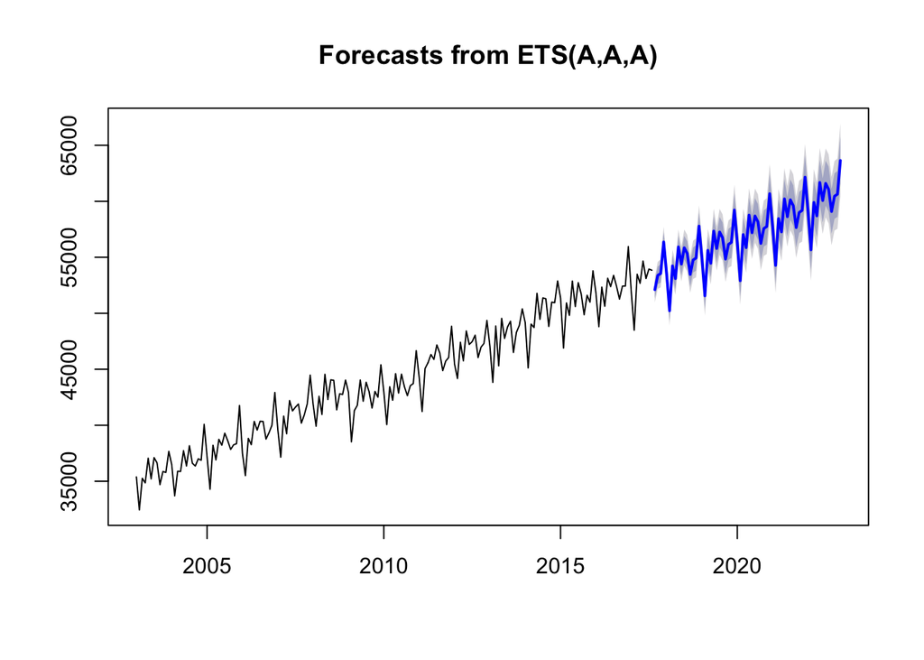

```r
fc<-forecast(ff,h = 64)
plot(fc)
```

### Analysis

- Since we cant compare the AICc and BIC, we will compare the RMSE and the MASE of the two models. The RMSE for model f is 494 and the MASE is .27 while the RMSE for ff is 532, and the MASE is .31. The model ff does slightly worse than the model f when compared against the measure of fit statistics.
- I expect the out of sample RMSE to be similar to the in sample RMSE but slightly greater because the training data will be fit more accurately than the test data. Similarly, the MAPE should be similar to the in sample MAPE but slightly greater. These results can be shown in number 7 where we have a very similar model but with a test set. The RMSE and MAPE out of sample and in sample are very close to each other.